# COD_week10_1_MGK_BTE3207

Minsik Kim

2024-11-04

# Before begin..

Let’s load the SBP dataset.

```r
dataset_sbp <- read.csv(file = "Inha/5_Lectures/2024/Advanced biostatistics/scripts/BTE3207_Advanced_Biostatistics/dataset/sbp_dataset_korea_2013-2014.csv")



head(dataset_sbp)
```

```
##   SEX BTH_G SBP DBP FBS DIS  BMI
## 1   1     1 116  78  94   4 16.6
## 2   1     1 100  60  79   4 22.3
## 3   1     1 100  60  87   4 21.9
## 4   1     1 111  70  72   4 20.2
## 5   1     1 120  80  98   4 20.0
## 6   1     1 115  79  95   4 23.1
```

Making a new variable `hypertension`

```r
dataset_sbp$hypertension <- ifelse(dataset_sbp$SBP > 130 |
                                           dataset_sbp$DBP > 80,
                                   T,
                                   F)
```

# DBP ~ SBP

With a scatter plot, we can see there is a correlation between SBP and DBP.

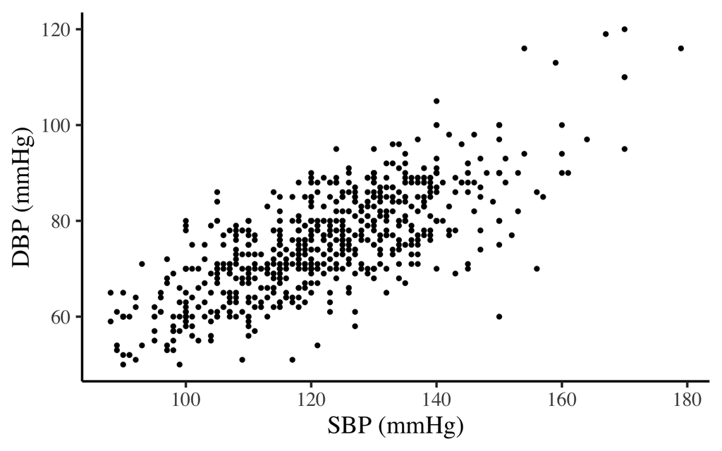

```r
set.seed(1)
dataset_sbp_small <- subset(dataset_sbp, row.names(dataset_sbp) %in% sample(x = 1:1000000, size = 1000))

ggplot(data = dataset_sbp_small, aes(x = SBP, y = DBP)) +
        geom_point() +
        theme_classic( base_family = "serif", base_size = 20) +
        xlab("SBP (mmHg)") +
        ylab("DBP (mmHg)")
```

# Data with trendline

With `lm()` function, we can calculate the linear model of DBP~SBP with the least squares algorithm.

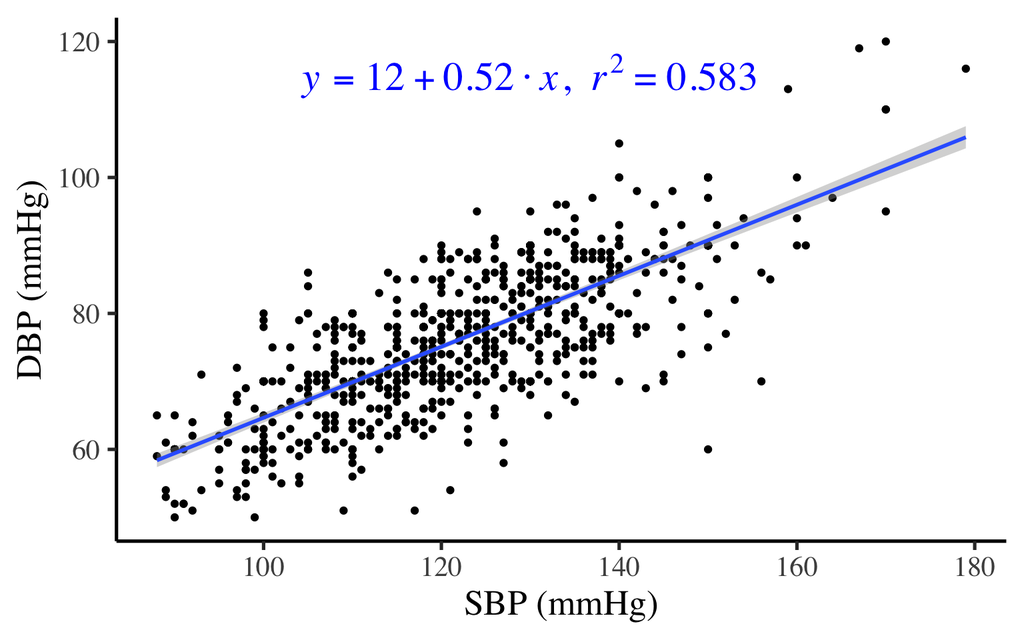

```r
#A function that returns equation

lm_eqn <- function(m){
    eq <- substitute(italic(y) == a + b %.% italic(x)*","~~italic(r)^2~"="~r2,
         list(a = format(unname(coef(m)[1]), digits = 2),
              b = format(unname(coef(m)[2]), digits = 2),
             r2 = format(summary(m)$r.squared, digits = 3)))
    as.character(as.expression(eq));
}


set.seed(1)

dataset_sbp_small <- subset(dataset_sbp, row.names(dataset_sbp) %in% sample(x = 1:1000000, size = 1000))

ggplot(data = dataset_sbp_small, aes(x = SBP, y = DBP)) +
        geom_point() +
        theme_classic(base_family = "serif", base_size = 20) +
        xlab("SBP (mmHg)") +
        ylab("DBP (mmHg)") +
        geom_smooth(method = "lm") +
        geom_label(x = 130, y = 115,
                  label = lm_eqn(lm(data = dataset_sbp_small, DBP ~ SBP)),
                  parse = TRUE,
                  family='serif',
                  size = 8, label.size = 0, color = "blue")
```

```r
#rnorm(100, mean = 100, sd = 1)
```

# Calculation of residual

The result of `Model's predicted value - sample` is called residual. It can be shown as below.

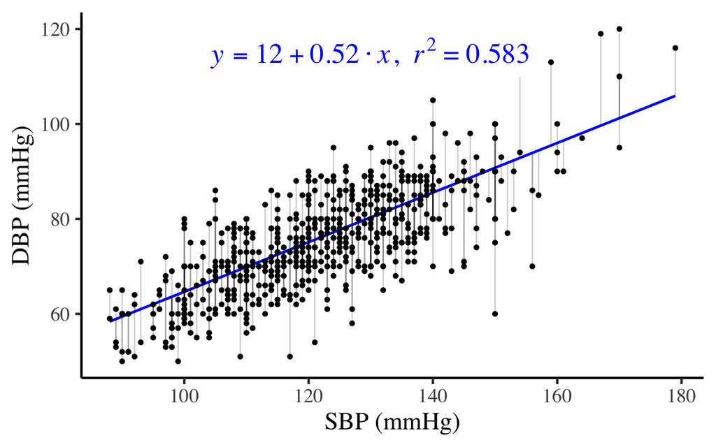

```r
lm_result <-
        lm(data = dataset_sbp_small,DBP ~ SBP) #%>% summary

d <- dataset_sbp_small


#Saving predicted values
d$predicted <- lm_result$fitted.values
d$residuals <- residuals(lm_result)


ggplot(d, aes(x = SBP, y = DBP)) +
        geom_smooth(method = "lm", se = FALSE, color = "blue") +  # Plot regression slope
        geom_segment(aes(xend = SBP, yend = predicted), alpha = .2) +  # alpha to fade lines
        geom_point() +
        xlab("SBP (mmHg)") +
        ylab("DBP (mmHg)") +
        theme_classic( base_family = "serif", base_size = 20) +
        geom_label(x = 130, y = 115,
                  label = lm_eqn(lm(data = dataset_sbp_small,DBP ~ SBP)),
                  parse = TRUE,
                  family='serif',
                  size = 8, label.size = 0, color = "blue")
```

# Intercept, slope, and their units

Remember that the size of intercept and slope is *DEPENDENT* on the units of input or outcome.

```r
dataset_sbp_small$SBP_pa <- 133.322 * dataset_sbp_small$SBP
dataset_sbp_small$DBP_pa <- 133.322 * dataset_sbp_small$DBP

dataset_sbp_small$SBP_psi <- 0.0193368 * dataset_sbp_small$SBP
dataset_sbp_small$DBP_psi <- 0.0193368 * dataset_sbp_small$DBP
```

If we chnage the units of SBP or DBP,

DBP (pascal) ~ SBP (pascal)

```r
lm(data = dataset_sbp_small, DBP_pa ~ SBP_pa) %>% summary
```

```
##
## Call:
## lm(formula = DBP_pa ~ SBP_pa, data = dataset_sbp_small)
##
## Residuals:
##     Min      1Q  Median      3Q     Max
## -4102.1  -611.7    16.4   623.6  3085.4
##
## Coefficients:
##              Estimate Std. Error t value Pr(>|t|)
## (Intercept) 1.657e+03  2.277e+02   7.275 6.99e-13 ***
## SBP_pa      5.223e-01  1.398e-02  37.372  < 2e-16 ***
## ---
## Signif. codes:  0 '***' 0.001 '**' 0.01 '*' 0.05 '.' 0.1 ' ' 1
##
## Residual standard error: 865 on 998 degrees of freedom
## Multiple R-squared:  0.5832, Adjusted R-squared:  0.5828
## F-statistic:  1397 on 1 and 998 DF,  p-value: < 2.2e-16
```

DBP (mmHg) ~ SBP (pascal)

```r
lm(data = dataset_sbp_small, DBP ~ SBP_pa) %>% summary
```

```
##
## Call:
## lm(formula = DBP ~ SBP_pa, data = dataset_sbp_small)
##
## Residuals:
##      Min       1Q   Median       3Q      Max
## -30.7682  -4.5884   0.1233   4.6775  23.1427
##
## Coefficients:
##              Estimate Std. Error t value Pr(>|t|)
## (Intercept) 1.243e+01  1.708e+00   7.275 6.99e-13 ***
## SBP_pa      3.917e-03  1.048e-04  37.372  < 2e-16 ***
## ---
## Signif. codes:  0 '***' 0.001 '**' 0.01 '*' 0.05 '.' 0.1 ' ' 1
##
## Residual standard error: 6.488 on 998 degrees of freedom
## Multiple R-squared:  0.5832, Adjusted R-squared:  0.5828
## F-statistic:  1397 on 1 and 998 DF,  p-value: < 2.2e-16
```

DBP (psi) ~ SBP (psi)

```r
lm(data = dataset_sbp_small, DBP_psi ~ SBP_psi) %>% summary
```

```
##
## Call:
## lm(formula = DBP_psi ~ SBP_psi, data = dataset_sbp_small)
##
## Residuals:
##      Min       1Q   Median       3Q      Max
## -0.59496 -0.08873  0.00238  0.09045  0.44751
##
## Coefficients:
##             Estimate Std. Error t value Pr(>|t|)
## (Intercept)  0.24026    0.03302   7.275 6.99e-13 ***
## SBP_psi      0.52229    0.01398  37.372  < 2e-16 ***
## ---
## Signif. codes:  0 '***' 0.001 '**' 0.01 '*' 0.05 '.' 0.1 ' ' 1
##
## Residual standard error: 0.1255 on 998 degrees of freedom
## Multiple R-squared:  0.5832, Adjusted R-squared:  0.5828
## F-statistic:  1397 on 1 and 998 DF,  p-value: < 2.2e-16
```

# Distance from the mean value can be drawn as below.

This is the residual from mean of all value - which is X-bar - Xi. Using them we can calcualte SD of mean!

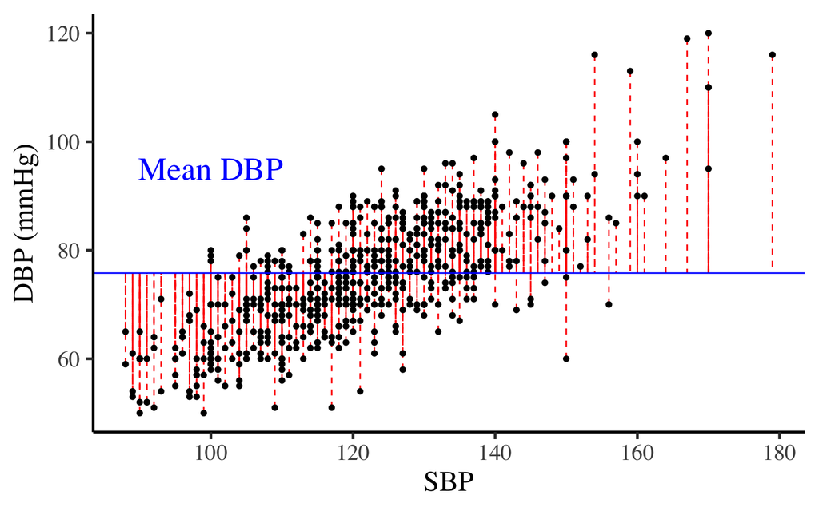

```r
#Saving predicted values
d$mean <- mean(dataset_sbp_small$DBP)
d$predicted <- lm_result$fitted.values
d$residuals <- residuals(lm_result)


ggplot(d, aes(x = SBP, y = DBP)) +
        #geom_smooth(method = "lm", se = FALSE, color = "blue") +  # Plot regression slope
        geom_segment(aes(xend = SBP, yend = mean), alpha = 1, linetype = "dashed", color = "red") +  # alpha to fade lines
        geom_point() +
        #xlab("SBP (mmHg)") +
        ylab("DBP (mmHg)") +
        theme_classic( base_family = "serif", base_size = 20) +
        geom_hline(yintercept = mean(dataset_sbp_small$DBP), color = "blue") +
        geom_label(x = 100, y = 95,
                  label = "Mean DBP",
                  #parse = TRUE,
                  family='serif',
                  size = 8, label.size = 0, color = "blue")
```

# Distance from a regression line can be drawn as below

With the same approach as above, we can calculate SD of a linear regression!

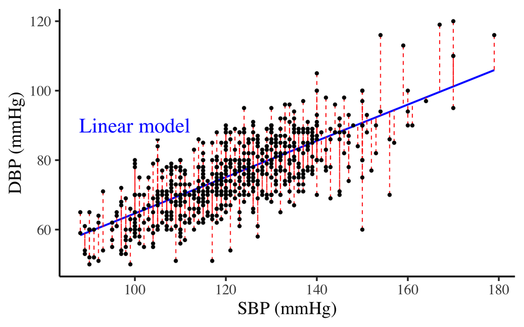

```r
lm_result <- dataset_sbp_small %>%
        lm(data = .,DBP ~ SBP) #%>% summary



ggplot(d, aes(x = SBP, y = DBP)) +
        geom_smooth(method = "lm", se = FALSE, color = "blue") +  # Plot regression slope
        geom_segment(aes(xend = SBP, yend = predicted), alpha = 1, linetype = "dashed", color = "red") +  # alpha to fade
        geom_point() +
        xlab("SBP (mmHg)") +
        ylab("DBP (mmHg)") +
        theme_classic( base_family = "serif", base_size = 20) +
        geom_label(x = 100, y = 90,
                  label = "Linear model",
                  #parse = TRUE,
                  family='serif',
                  size = 8, label.size = 0, color = "blue")
```

# Two draw both,

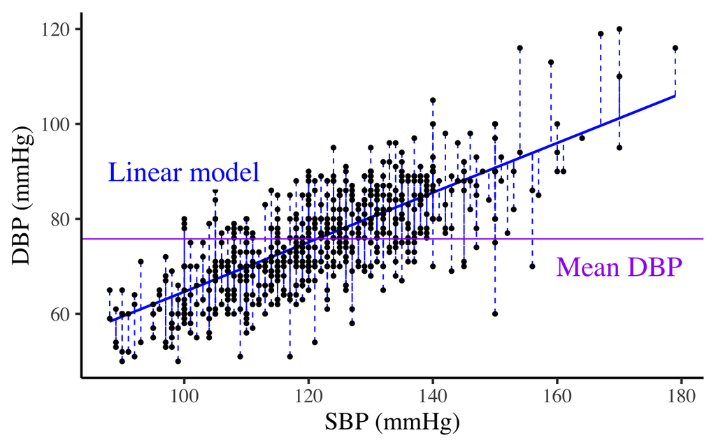

```r
ggplot(d, aes(x = SBP, y = DBP)) +
        geom_smooth(method = "lm", se = FALSE, color = "blue") +  # Plot regression slope
        geom_segment(aes(xend = SBP, yend = predicted), alpha = 1, linetype = "dashed", color = "blue") +  # alpha to fade
        #geom_segment(aes(xend = SBP, yend = mean), alpha = 1, linetype = "dashed", color = "purple") +  # alpha to fade
        geom_point() +
        xlab("SBP (mmHg)") +
        ylab("DBP (mmHg)") +
        theme_classic( base_family = "serif", base_size = 20) +
        geom_label(x = 100, y = 90,
                  label = "Linear model",
                  #parse = TRUE,
                  family='serif',
                  size = 8, label.size = 0, color = "blue") +
        geom_hline(yintercept = mean(dataset_sbp_small$DBP), color = "purple") +
        geom_label(x = 170, y = 70,
                  label = "Mean DBP",
                  #parse = TRUE,
                  family='serif',
                  size = 8, label.size = 0, color = "purple")
```

# Example 2 - BMI vs. SBP

R-squared is the measuremnt how the regression line fits well with the data.

With lower signifiacnt associations, R-squared value will be smaller.

```r
lm(data = dataset_sbp_small, BMI ~ SBP) %>% summary
```

```
##
## Call:
## lm(formula = BMI ~ SBP, data = dataset_sbp_small)
##
## Residuals:
##     Min      1Q  Median      3Q     Max
## -8.4686 -2.3082 -0.2373  1.9334 14.8563
##
## Coefficients:
##              Estimate Std. Error t value Pr(>|t|)
## (Intercept) 15.834783   0.850774  18.612   <2e-16 ***
## SBP          0.065282   0.006962   9.377   <2e-16 ***
## ---
## Signif. codes:  0 '***' 0.001 '**' 0.01 '*' 0.05 '.' 0.1 ' ' 1
##
## Residual standard error: 3.232 on 998 degrees of freedom
## Multiple R-squared:  0.08097,    Adjusted R-squared:  0.08005
## F-statistic: 87.93 on 1 and 998 DF,  p-value: < 2.2e-16
```

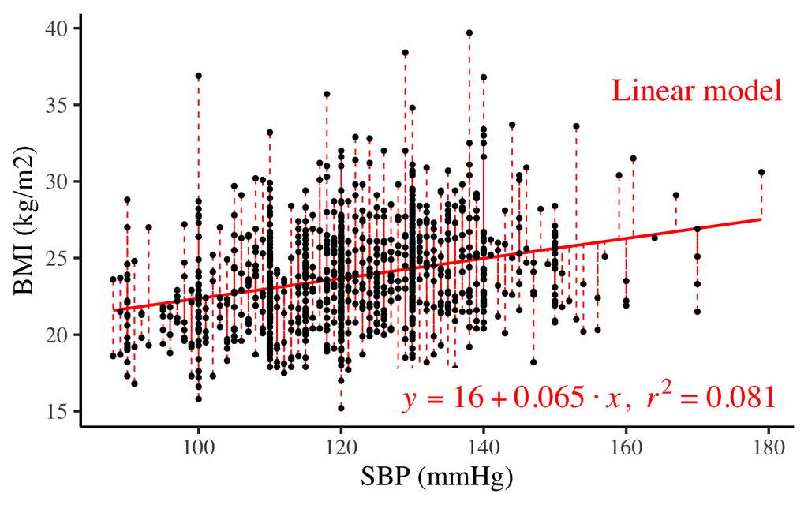

```r
BMI_model <- lm(data = dataset_sbp_small, BMI ~ SBP)

d$predicted <- BMI_model$fitted.values




ggplot(d, aes(x = SBP, y = BMI)) +
        geom_smooth(method = "lm", se = FALSE, color = "red") +  # Plot regression slope
        geom_segment(aes(xend = SBP, yend = predicted), alpha = 1, linetype = "dashed", color = "red") +  # alpha to fade
        #geom_segment(aes(xend = SBP, yend = mean), alpha = 1, linetype = "dashed", color = "purple") +  # alpha to fade
        geom_point() +
        xlab("SBP (mmHg)") +
        ylab("BMI (kg/m2)") +
        theme_classic( base_family = "serif", base_size = 20) +
        geom_label(x = 170, y = 36,
                  label = "Linear model",
                  #parse = TRUE,
                  family='serif',
                  size = 8, label.size = 0, color = "red") +
        #geom_hline(yintercept = mean(dataset_sbp_small$DBP), color = "purple") +
        geom_label(x = 155, y = 16,
                  label = lm_eqn(lm(data = dataset_sbp_small,BMI ~ SBP)),
                  parse = TRUE,
                  family='serif',
                  size = 8, label.size = 0, color = "red", fill = alpha(c("white"),1))
```

```r
        #ylim(c(11, 30))
```

# Example 3 - Binary variables

Linear model, confidence intervals of each term, p-values, and R-squared value can be calculated for binary input as well.

```r
dataset_sbp_small$Female <- ifelse(dataset_sbp_small$SEX == 1, 0, 1)

lm(data = dataset_sbp_small, DBP ~ Female) %>% summary
```

```
##
## Call:
## lm(formula = DBP ~ Female, data = dataset_sbp_small)
##
## Residuals:
##     Min      1Q  Median      3Q     Max
## -26.538  -7.538   0.083   6.083  46.083
##
## Coefficients:
##             Estimate Std. Error t value Pr(>|t|)
## (Intercept)  77.5377     0.4348 178.338  < 2e-16 ***
## Female       -3.6205     0.6256  -5.787 9.57e-09 ***
## ---
## Signif. codes:  0 '***' 0.001 '**' 0.01 '*' 0.05 '.' 0.1 ' ' 1
##
## Residual standard error: 9.886 on 998 degrees of freedom
## Multiple R-squared:  0.03247,    Adjusted R-squared:  0.0315
## F-statistic: 33.49 on 1 and 998 DF,  p-value: 9.57e-09
```

[figure not shown]

```r
gender_model <- lm(data = dataset_sbp_small, DBP ~ Female)

dataset_sbp_small$predicted <- gender_model$fitted.values




ggplot(dataset_sbp_small, aes(x = Female, y = DBP)) +
        geom_smooth(method = "lm", se = FALSE, color = "red") +  # Plot regression slope
        geom_segment(aes(xend = Female, yend = predicted), alpha = 1, linetype = "dashed", color = "red") +  # alpha to fade
        #geom_segment(aes(xend = SBP, yend = mean), alpha = 1, linetype = "dashed", color = "purple") +  # alpha to fade
        geom_point() +
        #xlab("") +
        scale_x_discrete(name ="Gender (Male = 0, Female = 1)",
                    limits=c(0,1)) +
        #scale_x_discrete(breaks = c(0,1))+
        ylab("BMI (kg/m2)") +
        theme_classic( base_family = "serif", base_size = 20) +
        geom_label(x = 0.5, y = 36,
                  label = "Linear model",
                  #parse = TRUE,
                  family='serif',
                  size = 8, label.size = 0, color = "red") +
        #geom_hline(yintercept = mean(dataset_sbp_small$DBP), color = "purple") +
        geom_label(x = 0.5, y = 120,
                  label = lm_eqn(lm(data = dataset_sbp_small,DBP ~ Female)),
                  parse = TRUE,
                  family='serif',
                  size = 8, label.size = 0, color = "red", fill = alpha(c("white"),1))
```

```r
        #ylim(c(11, 30))
```

# Pearson’s correlation

Pearson’s correlation can be calculated using `stats::cor()` function.

```r
#THis is Pearson's correlation coefficient
cor(dataset_sbp_small$DBP, dataset_sbp_small$SBP)
```

```
## [1] 0.7637024
```

```r
lm(data = dataset_sbp_small, SBP ~ SEX) %>% confint
```

```
##                  2.5 %     97.5 %
## (Intercept) 126.058909 131.684338
## SEX          -6.889471  -3.294782
```

Where, Pearson’s correlation is just the square root of R-squared!

```r
#It's sqrt() of R-squared.
sqrt(lm(data = dataset_sbp_small, DBP ~ SBP) %>% summary %>% .$r.squared)
```

```
## [1] 0.7637024
```

`stats::cor()` function will calculated multiple correlations at the same time!

```r
cor(dataset_sbp)
```

```
##                      SEX       BTH_G        SBP        DBP        FBS
## SEX           1.00000000  0.08522637 -0.1687964 -0.1904205 -0.1011504
## BTH_G         0.08522637  1.00000000  0.2759806  0.1344836  0.2139513
## SBP          -0.16879639  0.27598057  1.0000000  0.7430064  0.1865008
## DBP          -0.19042046  0.13448362  0.7430064  1.0000000  0.1387174
## FBS          -0.10115044  0.21395130  0.1865008  0.1387174  1.0000000
## DIS          -0.00479659 -0.47804876 -0.3107574 -0.1935247 -0.3159353
## BMI          -0.17083273  0.08808903  0.3043832  0.2754917  0.1736879
## hypertension -0.11345822  0.18508300  0.6975140  0.6676741  0.1307362
##                      DIS         BMI hypertension
## SEX          -0.00479659 -0.17083273   -0.1134582
## BTH_G        -0.47804876  0.08808903    0.1850830
## SBP          -0.31075745  0.30438319    0.6975140
## DBP          -0.19352467  0.27549170    0.6676741
## FBS          -0.31593533  0.17368791    0.1307362
## DIS           1.00000000 -0.20010681   -0.2226826
## BMI          -0.20010681  1.00000000    0.2225391
## hypertension -0.22268256  0.22253908    1.0000000
```

Other types of correlation - Spearman’s correlation (rank-based)

```r
cor(dataset_sbp,method = "spearman")
```

```
##                       SEX       BTH_G        SBP        DBP        FBS
## SEX           1.000000000  0.08885402 -0.1789945 -0.1922290 -0.1282142
## BTH_G         0.088854025  1.00000000  0.2724776  0.1401683  0.2719809
## SBP          -0.178994460  0.27247764  1.0000000  0.7287952  0.2348772
## DBP          -0.192228956  0.14016825  0.7287952  1.0000000  0.1818949
## FBS          -0.128214249  0.27198093  0.2348772  0.1818949  1.0000000
## DIS          -0.003510257 -0.48851313 -0.3018710 -0.1906525 -0.3085306
## BMI          -0.191643751  0.11242824  0.3159298  0.2762916  0.2292492
## hypertension -0.113458215  0.18404539  0.7143712  0.6864544  0.1657422
##                       DIS        BMI hypertension
## SEX          -0.003510257 -0.1916438   -0.1134582
## BTH_G        -0.488513132  0.1124282    0.1840454
## SBP          -0.301870974  0.3159298    0.7143712
## DBP          -0.190652466  0.2762916    0.6864544
## FBS          -0.308530592  0.2292492    0.1657422
## DIS           1.000000000 -0.2063562   -0.2228300
## BMI          -0.206356163  1.0000000    0.2229989
## hypertension -0.222829982  0.2229989    1.0000000
```

# Bibliography

[output not shown]